# 729周六作业

1.通过input输入一个字符，并判断它的类型，然后输出它是什么类型。 可以无限次输入，直至自己输入‘退出’才会结束。 例如：

- [1,24] --->print('您输入的是列表')
- Csd --->print('您输入的是字符串')

```python
data_types_dict = {
    "<class 'int'>": '整数',
    "<class 'float'>": '浮点数',
    "<class 'complex'>": '复数',
   "<class 'str'>": '字符串',
    "<class 'list'>": '列表',
   "<class 'tuple'>": '元组',
    "<class 'set'>": '集合',
    "<class 'dict'>": '字典',
    "<class 'bool'>": '布尔型',
    "<class 'NoneType'>": '空值',
    "<class 'file'>": '文件'
}
while True:
    x = input('请输入：')
    if x == '退出':
        print("已退出")
        break
    try:
        print(f'您输入的是{data_types_dict[str(type(eval(x)))]}')
    except:
        print("您输入的是字符串")
```

```
请输入：1
您输入的是整数
请输入：1.3
您输入的是浮点数
请输入：ll
您输入的是字符串
请输入：[]
您输入的是列表
请输入：()
您输入的是元组
请输入：{}
您输入的是字典
请输入：{45,56}
您输入的是集合
请输入：None
您输入的是空值
请输入：退出
已退出
```

```python
while True:
    x = input('请输入：')
    if x == '退出':
        print("已退出")
        break
    try:
        if type(eval(x)) == int:
            print('您输入的是整数')
        elif type(eval(x)) == float:
            print('您输入的是浮点数')
        elif type(eval(x)) == str:
            print('您输入的是字符串')
        elif type(eval(x)) == list:
            print('您输入的是列表')
        elif type(eval(x)) == tuple:
            print('您输入的是元组')
        elif type(eval(x)) == set:
            print('您输入的是集合')
        elif type(eval(x)) == dict:
            print('您输入的是字典')
        elif type(eval(x)) == bool:
            print('您输入的是布尔型')
        else:
            print('您输入的是空值')
    except:
        print("您输入的是字符串")
        pass
```

```
请输入：None
您输入的是空值
请输入：'None'
您输入的是字符串
请输入：退出
已退出
```

2.将字符串 去重并从小到大排序输出， 排序可用sorted()。 例如

- s = “ajldjlajfdljfddd”---->”adfjl”。

```python
s = 'ajldjlajfdljfddd'
print(''.join(sorted(set(s))))
```

```
adfjl
```

```python
s = input("请输入字符串：")
print(''.join(sorted(set(list(s)))))
```

```
请输入字符串：qwertyuioplkjhgfdsazxcvbnm
abcdefghijklmnopqrstuvwxyz
```

3.根据num.txt，设计函数，计算每个小列表里面的平均人数。 例如：

- ['1000人以上'] ----> 1000
- ['50-150人'] ----> （150+50）/2 = 100,
- [''] ----> 0 最终结果保存在列表中，例如：[['50-150人'], [''],['1000人以上'] ] --> [100,0,1000,...]

```python
with open('./data/num.txt','r') as f :
    num_data = f.read()
listes = num_data.replace('[','').replace(']','').replace("\'",'').replace('"','').replace('人','').replace('少于','').replace('以上','').replace(' ','').split(',')
num_avg = []
for i in listes:
    if i == '':
        num_avg.append(0)
    elif i.find('-') > 0:
        a = i.split('-')
        num_avg.append(int((eval(a[0])+eval(a[1]))/2))
    else:
        num_avg.append(eval(i))
print(num_avg)
```

[output not shown]

4.定义了一个 Car 类，它有 brand、model 和 year 属性，表示汽车的品牌、型号和制造年份。还有 speed 属性表示当前车速

- 类中定义三个方法：accelerate（加速）、brake（刹车）和 get_speed（获取速度）。
- accelerate可以输入加速参数increment表示加速了多少，输出经过加速后汽车的速度
- brake可以输入参数decrement表示减速了多少，输出减速后的汽车速度
- get_speed可以获取当前汽车的速度

```python
class Car:
    def __init__ (self,brand,model,year,speed):
        self.brand = brand # 品牌
        self.model = model # 型号
        self.year = year # 制造年份
        self.speed = speed # 车速
    def accelerate(self,increment):
        self.speed = self.speed+increment
        print(self.speed)
    def brake(self,decrement):
        if self.speed <= decrement:
            self.speed = 0
        else:
            self.speed = self.speed-decrement
        print(self.speed)
    def get_speed(self):
        return self.speed
```

```python
BMW = Car(brand='宝马',model='8系敞篷轿跑车',year=2000,speed=250)
BMW.accelerate(35)
BMW.brake(50)
BMW.brake(500)
BMW.accelerate(233)
BMW.get_speed()
```

```
285
235
0
233
```

```
233
```

5.内容判断 a = [1,2,3] 与 b = [3,2,1]，两个列表中的内容是一样的，怎么判断出来？ 提示：集合

```python
a = [1,2,3,'a']
b = [3,2,1,'a']
if set(a) == set(b):
    print("两个列表中的内容是一样的。")
else:
    print("两个列表中的内容不一样。")
```

```
两个列表中的内容是一样的。
```

6.（os、shutil模块的内容） 创建一个函数copy_directory，传入两个参数source_dir、destination_dir分别表示源文件夹和目标文件夹。 该函数作用是判断目标文件夹是否存在，如果不存在则新建，如果存在则把源文件夹下所有的内容复制到目标文件夹里面。

```python
import os
import shutil

def copy_directory(source_dir,destination_dir):
    if os.path.exists(destination_dir) == False:
        os.mkdir(destination_dir)
    for i in os.listdir(source_dir):
        source_item = os.path.join(source_dir,i)
        destination_item = os.path.join(destination_dir,i)
        if os.path.isfile(source_item):
            shutil.copy2(source_item,destination_item) #copy在目标文件不存在时进行复制,copy2函数会覆盖目标文件
        elif os.path.isdir(source_item):
            copy_directory(source_item,destination_item)
```

```python
source_dir = r'F:\Practical training 3\code\python\week1\data'
destination_dir = r'F:\Practical training 3\code\python\week1\data_1'
copy_directory(source_dir,destination_dir)
```

7.（有难度，可以不做）python程序设计思维，井字棋游戏：构建棋盘3X3的棋盘，X和O分别下棋，当三个棋连成线时胜出。已在board中给出棋盘的位置以及初始的字符串,并可以通过print_board()打印每次下棋后的棋盘结果。

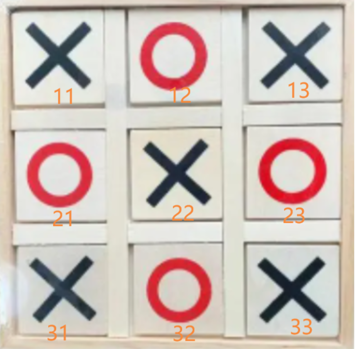

思路：

- A. 11，12，32等表示棋盘的位置，通过input提示X和O输入下棋的位置
- B. 对输入的位置判断是否合法，只能是11，12，13，21，22，23，31，32，33几个位置，并且位置被占用之后不能重新下棋， 例如：位置11被X占用之后，O不能再占用11。
- C.每走一步判断谁输谁赢（三个棋连成线则赢，思考该怎么完成这个判断过程？），直到一方胜出或者走完9步为止则游戏结束。

```python
board = [
    [' ',' ',' '],
    [' ',' ',' '],
    [' ',' ',' ']
]
b = 1
while True:
    global b
    x = input('请输入位置：')
    if x not in ('11','12','13','21','22','23','31','32','33'):
        print("输入不合法，请重写输入：")
        continue
    x = list(x)
    l = eval(x[0])-1
    r = eval(x[1])-1
    if board[l][r] != ' ':
        print("位置被占用，请重写输入：")
        continue
    elif b%2 == 1:
        board[l][r] = 'X'
        b+=1
    else:
        board[l][r] = '⚪'
        b+=1
    print_board()
    if referee(l,r):
        break
    if b>9:
        print("平局")
        break
```

```
请输入位置：22

 	X

请输入位置：11
⚪
 	X

请输入位置：33
⚪
 	X
 	 	X
请输入位置：13
⚪	 	⚪
 	X
 	 	X
请输入位置：21
⚪	 	⚪
X	X
 	 	X
请输入位置：23
⚪	 	⚪
X	X	⚪
 	 	X
请输入位置：12
⚪	X	⚪
X	X	⚪
 	 	X
请输入位置：31
⚪	X	⚪
X	X	⚪
⚪	 	X
请输入位置：32
⚪	X	⚪
X	X	⚪
⚪	X	X
X方获胜！
```

```python
def referee(a,b):
    global board
    if board[a][0]==board[a][b] and board[a][1]==board[a][b] and board[a][2]==board[a][b]:
        print(f'{board[a][b]}方获胜！')
        return True
    elif board[0][b]==board[a][b] and board[1][b]==board[a][b] and board[2][b]==board[a][b]:
        print(f'{board[a][b]}方获胜！')
        return True
    elif board[0][0]==board[a][b] and board[1][1]==board[a][b] and board[2][2]==board[a][b]:
        print(f'{board[a][b]}方获胜！')
        return True
    elif board[0][2]==board[a][b] and board[1][1]==board[a][b] and board[2][0]==board[a][b]:
        print(f'{board[a][b]}方获胜！')
        return True
    else:
        return False
```

```python
def print_board():
    global board
    for i in board:
        for j in i:
            print(j,end='\t')
        print('')
```